Skip to main content

# Predicting term deposit subscription

Author

Abdulrahman Aleid, Ahmed Muhaimin Choudhury, David Wu

Published

November 18, 2026

```python
import os
import zipfile
import requests
import pandas as pd
import altair as alt
from sklearn.model_selection import train_test_split
from sklearn.preprocessing import StandardScaler, OneHotEncoder, OrdinalEncoder, FunctionTransformer
from sklearn.compose import ColumnTransformer
from sklearn.pipeline import make_pipeline
from sklearn.dummy import DummyClassifier
from sklearn.linear_model import LogisticRegression
from sklearn.neighbors import KNeighborsClassifier
from sklearn.model_selection import cross_validate, StratifiedKFold
from sklearn.metrics import make_scorer, precision_score, recall_score, f1_score, accuracy_score

_ = alt.renderers.enable("png", scale_factor=2)
```

# Summary

In this project, we built a classification model to predict whether a bank client will subscribe to a term deposit, using only information available before the bank calls the client. We compared a Dummy Classifier, Logistic Regression and K-Nearest Neighbours using 5-fold cross-validation, and chose Logistic Regression as our final model. On the unseen test set, the final model had an accuracy of 0.889, a precision of 0.584 and a recall of 0.170. This means that when the model predicts a client will subscribe, it is correct about 58.4% of the time, which is much better than the overall subscription rate of about 11.7%, but it finds only about 17% of the clients who actually subscribe. The model could help the bank decide which clients to call first, but further work, such as handling the class imbalance, is needed to improve its recall before it is used in practice.

# Introduction

A term deposit is a bank account where a client keeps money for a fixed period of time and earns a fixed interest rate, but usually cannot withdraw the money early without paying a penalty. Term deposits are useful for banks because they give the bank a stable source of money that it can use, for example, to give loans. To sell term deposits, banks often run direct marketing campaigns, in which staff call clients and offer them the product. However, most clients who are contacted do not subscribe, so calling everyone costs the bank a lot of time and money, and may also annoy clients. A model that can predict which clients are likely to subscribe could help the bank decide which clients to prioritize.

In this project, we asked whether we can predict if a bank client will subscribe to a term deposit, using only information the bank has before calling the client. We used the Bank Marketing data set from the UCI Machine Learning Repository, which contains data from phone marketing campaigns of a Portuguese bank (Moro, Rita, and Cortez 2014). Each row in the data set represents one client who was contacted during a campaign, and includes information about the client, such as their age and type of job, and about the contact, such as the month of the call. The target is whether the client subscribed to a term deposit (yes or no).

# Methods

## Data

```python
# create the data folders if they don't exist
os.makedirs("../data/raw", exist_ok=True)
os.makedirs("../data/processed", exist_ok=True)

# download the zip file from the UCI Machine Learning Repository
url = "https://archive.ics.uci.edu/static/public/222/bank+marketing.zip"
zip_path = "../data/raw/bank+marketing.zip"

response = requests.get(url)
response.raise_for_status()  # stop with an error if the download failed
with open(zip_path, "wb") as f:
    f.write(response.content)

with zipfile.ZipFile(zip_path) as z:
    z.extractall("../data/raw")

with zipfile.ZipFile("../data/raw/bank.zip") as z:
    z.extractall("../data/raw")
```

```python
# read in the full data set
bank = pd.read_csv("../data/raw/bank-full.csv", sep=";")
```

Before cleaning the data, we checked that the download was complete and that the file has no empty cells or duplicate rows (Table 1). These checks only confirm that the file was read correctly, so they do not use any information that could influence our modelling decisions.

**Table 1.** Basic checks of the full data set.

```python
pd.DataFrame({
    "Check": ["Number of rows", "Number of columns", "Empty cells", "Duplicate rows"],
    "Result": [
        bank.shape[0],
        bank.shape[1],
        bank.isna().sum().sum(),
        bank.duplicated().sum()
    ]
}).set_index("Check")
```

| Check | Result |
| --- | --- |
| Number of rows | 45211 |
| Number of columns | 17 |
| Empty cells | 0 |
| Duplicate rows | 0 |

We removed the call duration variable before modelling. The duration of a call is only known after the call has ended, and by then the outcome (whether the client subscribed) is also known. A model that uses call duration therefore cannot help the bank decide which clients to call, which is the purpose of our analysis. This decision is based on the meaning of the variable, not on the data, so it is safe to make before splitting the data.

```python
# drop duration: it is only known after the call ends,
# so it cannot be used to predict before calling a client
bank_clean = bank.drop(columns=["duration"])
bank_clean.to_csv("../data/processed/bank_clean.csv", index=False)
```

We then split the data into a training set (80%) and a test set (20%). We split the data before any further exploration, so that the test set does not influence any decision we make. Because only a small share of clients subscribed to a term deposit, we used a stratified split, which keeps the same proportion of subscribers in both sets.

```python
# split the data into training (80%) and test (20%) sets
bank_train, bank_test = train_test_split(
    bank_clean,
    test_size=0.2,
    stratify=bank_clean["y"],
    random_state=522
)

bank_train.to_csv("../data/processed/bank_train.csv", index=False)
bank_test.to_csv("../data/processed/bank_test.csv", index=False)
```

## Data quality in the training set

Although the data set has no empty cells, some categorical variables record missing information as the value “unknown” (Table 2). This affects four variables in the training set: job, education, contact type and the outcome of the previous campaign.

**Table 2.** Number and percentage of “unknown” values in the training set, for the variables that contain them.

```python
# count "unknown" values in each column of the training set
unknown_counts = (bank_train == "unknown").sum()
unknown_counts = unknown_counts[unknown_counts > 0]

unknown_table = pd.DataFrame({
    "Number of unknown values": unknown_counts,
    "Percent of training rows": (unknown_counts / len(bank_train) * 100).round(1)
}).rename(index={
    "job": "Job",
    "education": "Education",
    "contact": "Contact type",
    "poutcome": "Previous campaign outcome"
})
unknown_table.index.name = "Variable"
unknown_table
```

| Variable | Number of unknown values | Percent of training rows |
| --- | --- | --- |
| Job | 232 | 0.6 |
| Education | 1463 | 4.0 |
| Contact type | 10467 | 28.9 |
| Previous campaign outcome | 29567 | 81.7 |

To understand the “unknown” values in the previous campaign outcome, we compared this variable with the number of days since the client was last contacted in a previous campaign. The data set uses -1 for clients who were not previously contacted (Table 3).

**Table 3.** Number of clients in the training set with an unknown previous campaign outcome, and how many of them were not previously contacted.

```python
# keep only the clients whose previous campaign outcome is "unknown"
unknown_poutcome = bank_train[bank_train["poutcome"] == "unknown"]

# count how many of them were not previously contacted (pdays == -1)
n_unknown = len(unknown_poutcome)
n_not_contacted = (unknown_poutcome["pdays"] == -1).sum()

pd.DataFrame({
    "Unknown previous outcome": [n_unknown],
    "Not previously contacted": [n_not_contacted],
    "Percent": [round(n_not_contacted / n_unknown * 100, 2)]
}, index=["Training set"])
```

|  | Unknown previous outcome | Not previously contacted | Percent |
| --- | --- | --- | --- |
| Training set | 29567 | 29563 | 99.99 |

Almost all clients with an unknown previous campaign outcome (29,563 of 29,567, or 99.99%) were not contacted in a previous campaign (Table 3). For this variable, “unknown” therefore does not represent missing information: it means that there was no previous campaign for that client. For the other three variables, the “unknown” values are true missing information, but we kept them as well. Removing these rows would discard a large part of the data, because almost a third of the clients in the training set have an unknown contact type (Table 2). We therefore kept “unknown” as its own category in all four variables, so that the model can learn from it like any other category.

## Exploratory data analysis (EDA)

### Target class composition

To choose suitable evaluation metrics, we first checked whether the target classes are balanced (Table 4 and Figure 1). The classes are highly imbalanced: 88.3% of the clients in the training set did not subscribe. Accuracy alone would therefore be misleading, so we also used precision, recall and F1 score.

**Table 4.** Target class composition in the training data

```python
target_counts = (
    bank_train["y"]
    .value_counts()
    .rename_axis("subscribed")
    .reset_index(name= "count")
)

target_counts["percent"] = (target_counts["count"]/len(bank_train) * 100).round(1)

target_table = (
    target_counts
    .set_index("subscribed")
    .rename(
        index={"no": "Did not subscribe", "yes": "Subscribed"},
        columns={"count": "Number of clients", "percent": "Percent of training rows"}
    )
)
target_table.index.name = "Outcome"
target_table
```

| Outcome | Number of clients | Percent of training rows |
| --- | --- | --- |
| Did not subscribe | 31937 | 88.3 |
| Subscribed | 4231 | 11.7 |

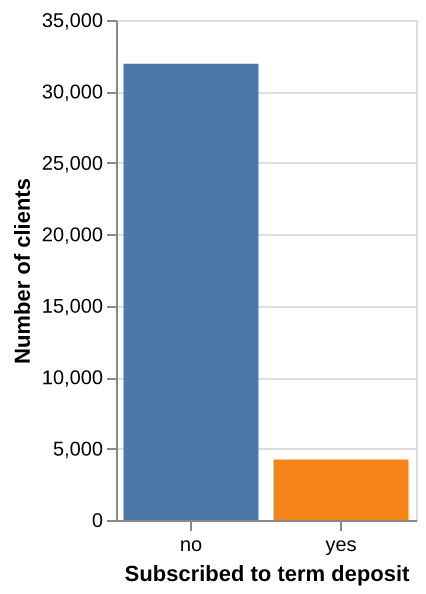

```python
target_chart = (
    alt.Chart(target_counts)
    .mark_bar()
    .encode(
        x=alt.X("subscribed:N", title = "Subscribed to term deposit",
               axis=alt.Axis(labelAngle =0)),
        y=alt.Y("count:Q", title = "Number of clients"),
        color=alt.Color("subscribed:N", legend = None)
    )
    .properties(width=150, height=250)
)

target_chart
```

**Figure 1.** Class imbalance of the target in training data for term deposit subscription

### Descriptive summary of individual features

We first looked at summary statistics of the numeric features (Table 5). The numeric features are heavily right-skewed, and their scales vary widely: age ranges from 18 to 95 and campaign contacts from 1 to 63, while balance ranges from -8,019 to 102,127 euros and previous contacts from 0 to 275. We therefore included a scaler for the numeric features in our pipeline. The number of days since the previous contact ranges from -1 to 871, but its only useful signal is whether the client was contacted before, so we converted it into a binary feature for the charts and the model.

**Table 5.** Summary of numeric features

```python
summary_cols = ["age", "balance", "campaign", "pdays", "previous"]

num_summary = (
    bank_train[summary_cols]
    .describe()
    .T[["mean", "50%", "min", "max"]]
    .round(1)
    .rename(
        index={
            "age": "Age (years)",
            "balance": "Balance (euros)",
            "campaign": "Campaign contacts",
            "pdays": "Days since previous contact",
            "previous": "Contacts before this campaign"
        },
        columns={"mean": "Mean", "50%": "Median", "min": "Minimum", "max": "Maximum"}
    )
)
num_summary.index.name = "Feature"
num_summary
```

| Feature | Mean | Median | Minimum | Maximum |
| --- | --- | --- | --- | --- |
| Age (years) | 40.9 | 39.0 | 18.0 | 95.0 |
| Balance (euros) | 1363.7 | 446.0 | -8019.0 | 102127.0 |
| Campaign contacts | 2.8 | 2.0 | 1.0 | 63.0 |
| Days since previous contact | 40.1 | -1.0 | -1.0 | 871.0 |
| Contacts before this campaign | 0.6 | 0.0 | 0.0 | 275.0 |

Table 6 summarizes the categorical features: the number of levels, the most common level and its share, and whether the feature contains “unknown” values.

**Table 6.** Summary of categorical features

```python
cat_cols = ["job", "marital", "education", "default", "housing",
            "loan", "contact", "month", "poutcome"]

cat_summary = pd.DataFrame({
    "Feature": cat_cols,
    "Levels": [bank_train[col].nunique() for col in cat_cols],
    "Most common level": [bank_train[col].value_counts().index[0] for col in cat_cols],
    "Most common %": [round(bank_train[col].value_counts(normalize=True).iloc[0] * 100, 1)
                      for col in cat_cols],
    "Has 'unknown'": ["unknown" in bank_train[col].unique() for col in cat_cols],
}).set_index("Feature").rename(index={
    "job": "Job",
    "marital": "Marital status",
    "education": "Education",
    "default": "Has credit in default",
    "housing": "Has housing loan",
    "loan": "Has personal loan",
    "contact": "Contact type",
    "month": "Last contact month",
    "poutcome": "Previous campaign outcome"
})
cat_summary["Has 'unknown'"] = cat_summary["Has 'unknown'"].map({True: "Yes", False: "No"})
cat_summary
```

| Feature | Levels | Most common level | Most common % | Has 'unknown' |
| --- | --- | --- | --- | --- |
| Job | 12 | blue-collar | 21.6 | Yes |
| Marital status | 3 | married | 60.3 | No |
| Education | 4 | secondary | 51.4 | Yes |
| Has credit in default | 2 | no | 98.2 | No |
| Has housing loan | 2 | yes | 55.7 | No |
| Has personal loan | 2 | no | 84.0 | No |
| Contact type | 3 | cellular | 64.6 | Yes |
| Last contact month | 12 | may | 30.7 | No |
| Previous campaign outcome | 4 | unknown | 81.7 | Yes |

### Binary features

To see whether the binary and categorical features are useful for predicting subscription, we calculated the subscription rate for each level of each feature and compared these rates in bar charts. We split them into three charts: one for binary features, one for categorical features with 3 or 4 levels, and one for categorical features with more than 4 levels. Figure 2 shows that previous contact has the strongest signal among the binary features: clients who were contacted before had a subscription rate about 15 percentage points higher than clients contacted for the first time. Having a housing loan also shows a clear difference: clients without a housing loan had a subscription rate about 10 percentage points higher than clients with one.

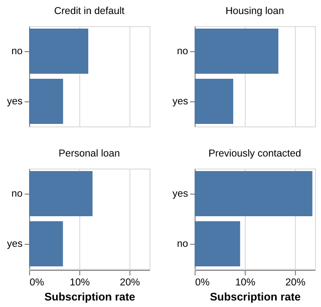

```python
def subscription_rate(df, col):
    return(
        df.assign(subscribed=(df["y"]=="yes"))
        .groupby(col)["subscribed"].mean()
        .reset_index(name="rate")
    )

bank_train_eda = bank_train.assign(previously_contacted = (bank_train["pdays"]!= -1).map({True: "yes", False: "no"}))

feature_labels = {
    "housing": "Housing loan", "loan": "Personal loan",
    "default": "Credit in default", "previously_contacted": "Previously contacted",
    "contact": "Contact type", "education": "Education",
    "marital": "Marital status", "poutcome": "Previous campaign outcome",
    "month": "Last contact month", "job": "Job"
}

bi_cols = ["housing", "loan", "default", "previously_contacted"]

bi_perc = []

for col in bi_cols:
    r = subscription_rate(bank_train_eda, col).rename(columns = {col:"category"})
    r ["feature"] = feature_labels[col]
    bi_perc.append(r)

rates_bi = pd.concat(bi_perc, ignore_index=True)

bi_chart = (
    alt.Chart(rates_bi)
    .mark_bar()
    .encode(
        x=alt.X("rate:Q", title = "Subscription rate", axis=alt.Axis(format="%")),
        y=alt.Y("category:N", sort = "-x", title = None)
        )
    .properties(width=120, height=100)
    .facet(facet=alt.Facet("feature:N", title=None), columns=2)
    .resolve_scale(y="independent")
)

bi_chart
```

**Figure 2.** Comparison of term deposit subscription rate between binary features of training data

### Categorical features

Next, we looked at the categorical features with 3 or 4 levels (Figure 3). For marital status, contact type and education, the subscription rate does not vary much across levels. For the previous campaign outcome, however, clients whose previous campaign was a success have a much higher subscription rate than clients with other outcomes. Among the categorical features with more than 4 levels (Figure 4), the last contact month shows higher subscription rates in March, September, October and December. For job, students, who usually do not have fixed income, have the highest subscription rate. However, the differences between jobs are smaller than for the previous campaign outcome, so job is likely a weaker signal.

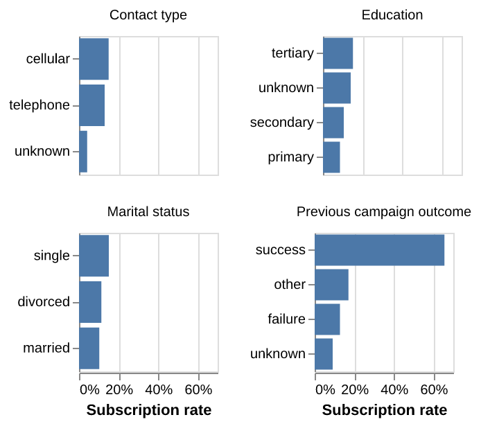

```python
cat_cols34 = ["contact", "education", "marital", "poutcome"]

cat_perc34 = []

for col in cat_cols34:
    r = subscription_rate(bank_train_eda, col).rename(columns = {col:"category"})
    r ["feature"] = feature_labels[col]
    cat_perc34.append(r)

rates_cat34 = pd.concat(cat_perc34, ignore_index=True)

cat34_chart = (
    alt.Chart(rates_cat34)
    .mark_bar()
    .encode(
        x=alt.X("rate:Q", title = "Subscription rate", axis=alt.Axis(format="%")),
        y=alt.Y("category:N", sort = "-x", title = None)
        )
    .properties(width=100, height=100)
    .facet(facet=alt.Facet("feature:N", title=None), columns=2)
    .resolve_scale(y="independent")
)


cat34_chart
```

**Figure 3.** Comparison of term deposit subscription rate between categorical features training data with 3/4 levels

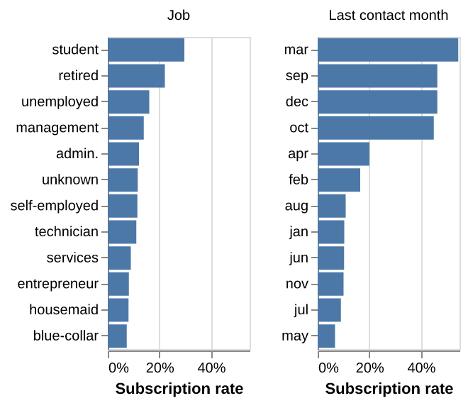

```python
cat_cols_more = ["month", "job"]

cat_perc_more = []

for col in cat_cols_more:
    r = subscription_rate(bank_train_eda, col).rename(columns = {col:"category"})
    r ["feature"] = feature_labels[col]
    cat_perc_more.append(r)

rates_cat_more = pd.concat(cat_perc_more, ignore_index=True)

cat_more_chart = (
    alt.Chart(rates_cat_more)
    .mark_bar()
    .encode(
        x=alt.X("rate:Q", title = "Subscription rate", axis=alt.Axis(format="%")),
        y=alt.Y("category:N", sort = "-x", title = None)
        )
    .properties(width=100, height=220)
    .facet(facet=alt.Facet("feature:N", title=None), columns=2)
    .resolve_scale(y="independent")
)

cat_more_chart
```

**Figure 4.** Comparison of term deposit subscription rate between categorical features of training data with more than 4 levels

Figure 5 compares the subscription rate for each previous campaign outcome with the baseline subscription rate (dashed line). Clients whose previous campaign was a success had a much higher subscription rate than the baseline and than all other outcomes (49 percentage points higher than the next highest outcome). This suggests that the previous campaign outcome is a strong predictor of subscription.

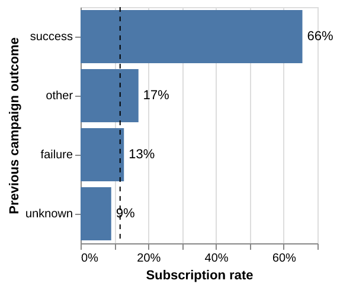

```python
baseline = (bank_train["y"] == "yes").mean()

poutcome_rate = subscription_rate(bank_train, "poutcome")

order = poutcome_rate.sort_values("rate", ascending=False)["poutcome"].tolist()

poutcome_chart = (
    alt.Chart(poutcome_rate)
    .mark_bar()
    .encode(
        x=alt.X("rate:Q", title = "Subscription rate", axis=alt.Axis(format="%")),
        y=alt.Y("poutcome:N", sort = order, title = "Previous campaign outcome"),
    )
    .properties(width=200, height=200)
)

baseline_rule = alt.Chart(alt.Data(values=[{"b":baseline}])).mark_rule(strokeDash =[4,4]).encode(x="b:Q")

labels =(alt.Chart(poutcome_rate)
         .mark_text(align = "left", dx=4, color="black")
         .encode(
             x=alt.X("rate:Q"),
             y=alt.Y("poutcome:N", sort= order),
             text=alt.Text("rate:Q", format =".0%")
         )
)
poutcome_chart + baseline_rule +labels
```

**Figure 5.** Comparison between different levels of previous campaign outcome and the baseline average subscription rate

### Numeric features

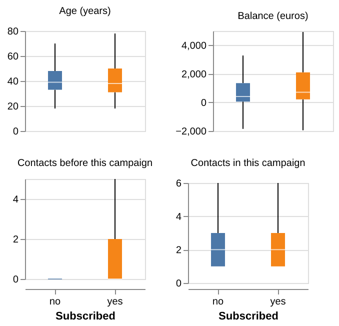

```python
num_cols = ["age", "balance", "campaign", "previous"]

num_df = bank_train.melt(
    id_vars="y", value_vars=num_cols,
    var_name="feature", value_name = "value"
)

num_labels = {
    "age": "Age (years)", "balance": "Balance (euros)",
    "campaign": "Contacts in this campaign", "previous": "Contacts before this campaign"
}
num_df["feature"] = num_df["feature"].map(num_labels)

alt.data_transformers.enable("vegafusion")

num_chart = (
    alt.Chart(num_df)
    .mark_boxplot(outliers=False)
    .encode(
        x=alt.X("y:N", title="Subscribed", axis=alt.Axis(labelAngle =0)),
        y=alt.Y("value:Q", title=None),
        color=alt.Color("y:N", legend=None)
    )
    .properties(width=120, height=100)
    .facet(facet=alt.Facet("feature:N", title=None), columns = 2)
    .resolve_scale(y="independent")
)


num_chart
```

**Figure 6.** Distributions of numeric features of training data by subscription outcome (outliers not shown)

## Analysis

The Python programming language (Van Rossum and Drake 2009) and the following Python packages were used to perform the analysis: requests (Reitz 2011), zipfile (Van Rossum and Drake 2009), pandas (McKinney 2010), Altair (VanderPlas et al. 2018) and scikit-learn (Pedregosa et al. 2011). The code used to perform the analysis and create this report can be found here: https://github.com/UBC-MDS-2026-27/DSCI-522-GROUP-6-Predicting_term_deposit_subscription.

First, we examined the features based on their definitions and relevance to predicting term deposit subscriptions. The duration feature represents the duration of the last contact with a client, measured in seconds. Since this information is only available after a call has taken place, including it would introduce data leakage when predicting whether a client will subscribe before making the call. Therefore, we excluded duration from the analysis.

Second, we divided the features into three main categories: numerical, categorical, and binary. Binary features can be represented in different formats, such as 0 and 1 or “yes” and “no”. These features were identified and processed according to their data types and meanings.

One feature requiring special attention was `pdays`, which represents the number of days since a client was last contacted during a previous campaign. A value of -1 indicates that the client had not been previously contacted, while non-negative values indicate the number of days since the previous contact. Since -1 has a different meaning from non-negative values, treating all values as ordinary numerical observations would be inappropriate. Additionally, most observations had a value of -1. Therefore, we transformed `pdays` into a new binary feature called `previously_contacted`, where -1 was encoded as 0 and all non-negative values were encoded as 1. This transformation distinguishes clients who had been previously contacted from those who had not, although it removes information about the exact number of days since the previous contact.

We treated the month of the last contact as a categorical feature, because months have no natural order that matters for subscription, and the subscription rate differed a lot between months (Figure 4). We dropped the day of the month, because treating it as a numeric feature would mean that day 31 is “more” than day 1, and it was not clearly linked to subscription.

```python
X_train = bank_train.drop(columns="y")
y_train = bank_train["y"]

X_test = bank_test.drop(columns="y")
y_test = bank_test["y"]

def transform_pdays(X):
    X = X.copy()
    X["previously_contacted"] = (X["pdays"] != -1).astype(int)
    return X.drop(columns=["pdays"])

numeric_features = ["age", "balance", "campaign", "previous"]
categorical_features = ["job", "marital", "education", "contact", "month", "poutcome"]
binary_features = ["default", "housing", "loan"]
contacted_features = ["previously_contacted"]
```

```python
numeric_pipe = make_pipeline(StandardScaler())

categorical_pipe = make_pipeline(OneHotEncoder(handle_unknown="ignore"))

binary_pipe = make_pipeline(OrdinalEncoder(categories=[["no", "yes"]] * len(binary_features)))

preprocessor = ColumnTransformer(
    transformers=[
        ("numeric", numeric_pipe, numeric_features),
        ("categorical", categorical_pipe, categorical_features),
        ("binary", binary_pipe, binary_features),
        ("contacted", "passthrough", contacted_features)
    ],
    remainder="drop",
    verbose_feature_names_out=False
)

full_preprocessor = make_pipeline(
    FunctionTransformer(transform_pdays, validate=False),
    preprocessor
)
```

We used a Dummy Classifier as the baseline and compared it with two candidate models: Logistic Regression and K-Nearest Neighbours. All three models were evaluated with 5-fold cross-validation.

As Table 7 shows, the Dummy Classifier achieved a validation accuracy of 0.883, but its F1 score was 0, which means that it did not identify any clients who subscribed to a term deposit. This is because it always predicts the most common class (“no”), and 88.3% of the clients in the training set did not subscribe.

**Table 7.** Cross-validation results of the Dummy Classifier.

```python
dummy_pipe = make_pipeline(
    full_preprocessor,
    DummyClassifier(strategy="most_frequent")
)

cv = StratifiedKFold(
    n_splits=5,
    shuffle=True,
    random_state=123
)

scoring = {
    "accuracy": "accuracy",
    "precision": make_scorer(precision_score, pos_label="yes", zero_division=0),
    "recall": make_scorer(recall_score, pos_label="yes", zero_division=0),
    "f1": make_scorer(f1_score, pos_label="yes", zero_division=0)
}

dummy_scores = cross_validate(
    dummy_pipe,
    X_train,
    y_train,
    cv=cv,
    scoring=scoring,
    return_train_score=True
)

dummy_results = pd.DataFrame({
    "Metric": ["Accuracy", "Precision", "Recall", "F1"],
    "Train": [
        dummy_scores["train_accuracy"].mean(),
        dummy_scores["train_precision"].mean(),
        dummy_scores["train_recall"].mean(),
        dummy_scores["train_f1"].mean()
    ],
    "Validation": [
        dummy_scores["test_accuracy"].mean(),
        dummy_scores["test_precision"].mean(),
        dummy_scores["test_recall"].mean(),
        dummy_scores["test_f1"].mean()
    ]
})

display(dummy_results.set_index("Metric").round(3))
```

| Metric | Train | Validation |
| --- | --- | --- |
| Accuracy | 0.883 | 0.883 |
| Precision | 0.000 | 0.000 |
| Recall | 0.000 | 0.000 |
| F1 | 0.000 | 0.000 |

As Table 8 shows, Logistic Regression had a validation accuracy of 0.893, a precision of 0.641, a recall of 0.189 and an F1 score of 0.292. All of these scores are higher than those of the Dummy Classifier, so this model is a better choice than the baseline. Low recall is one problem of the Logistic Regression model: it correctly identified only about 18.9% of the clients who actually subscribed to a term deposit, and missed approximately 81.1% of them. This suggests that the model is relatively conservative when predicting the positive class. One possible reason is the class imbalance in the data set, which may cause the model to favour the majority class. To improve recall, we could use `class_weight="balanced"` or adjust the classification threshold, although these changes may reduce precision.

**Table 8.** Cross-validation results of Logistic Regression.

```python
reg_pipe = make_pipeline(
    full_preprocessor,
    LogisticRegression(max_iter=2000, random_state=123)
)

reg_scores = cross_validate(
    reg_pipe,
    X_train,
    y_train,
    cv=cv,
    scoring=scoring,
    return_train_score=True
)

reg_results = pd.DataFrame({
    "Metric": ["Accuracy", "Precision", "Recall", "F1"],
    "Train": [
        reg_scores["train_accuracy"].mean(),
        reg_scores["train_precision"].mean(),
        reg_scores["train_recall"].mean(),
        reg_scores["train_f1"].mean()
    ],
    "Validation": [
        reg_scores["test_accuracy"].mean(),
        reg_scores["test_precision"].mean(),
        reg_scores["test_recall"].mean(),
        reg_scores["test_f1"].mean()
    ]
})

display(reg_results.set_index("Metric").round(3))
```

| Metric | Train | Validation |
| --- | --- | --- |
| Accuracy | 0.894 | 0.893 |
| Precision | 0.652 | 0.641 |
| Recall | 0.193 | 0.189 |
| F1 | 0.297 | 0.292 |

As Table 9 shows, the KNN model had a validation accuracy of 0.886, a precision of 0.536, a recall of 0.211 and an F1 score of 0.303. All of these scores are higher than those of the Dummy Classifier.

**Table 9.** Cross-validation results of K-Nearest Neighbours.

```python
knn_pipe = make_pipeline(
    full_preprocessor,
    KNeighborsClassifier(n_neighbors=5)
)

knn_scores = cross_validate(
    knn_pipe,
    X_train,
    y_train,
    cv=cv,
    scoring=scoring,
    return_train_score=True
)

knn_results = pd.DataFrame({
    "Metric": ["Accuracy", "Precision", "Recall", "F1"],
    "Train": [
        knn_scores["train_accuracy"].mean(),
        knn_scores["train_precision"].mean(),
        knn_scores["train_recall"].mean(),
        knn_scores["train_f1"].mean()
    ],
    "Validation": [
        knn_scores["test_accuracy"].mean(),
        knn_scores["test_precision"].mean(),
        knn_scores["test_recall"].mean(),
        knn_scores["test_f1"].mean()
    ]
})

display(knn_results.set_index("Metric").round(3))
```

| Metric | Train | Validation |
| --- | --- | --- |
| Accuracy | 0.906 | 0.886 |
| Precision | 0.730 | 0.536 |
| Recall | 0.312 | 0.211 |
| F1 | 0.437 | 0.303 |

**Table 10.** Validation scores of the three models.

```python
comparison_df = pd.concat([
    dummy_results.assign(Model="Dummy"),
    reg_results.assign(Model="Logistic Regression"),
    knn_results.assign(Model="KNN")
], ignore_index=True)

display(comparison_df.pivot(index="Model", columns="Metric", values="Validation")[["Accuracy", "Precision", "Recall", "F1"]].round(3))
```

| Metric Model | Accuracy | Precision | Recall | F1 |
| --- | --- | --- | --- | --- |
| Dummy | 0.883 | 0.000 | 0.000 | 0.000 |
| KNN | 0.886 | 0.536 | 0.211 | 0.303 |
| Logistic Regression | 0.893 | 0.641 | 0.189 | 0.292 |

Therefore, we chose Logistic Regression as our final model. Although KNN had a slightly higher validation F1 score (0.303 compared with 0.292), Logistic Regression had a higher validation precision (0.641 compared with 0.536) and a much smaller gap between its training and validation F1 scores, which means it is less likely to be overfitting.

# Results

We fitted the final Logistic Regression model on the whole training set and evaluated it once on the test set (Table 11). The model reached an accuracy of 0.889, which is only slightly higher than the accuracy of the Dummy Classifier (0.883), because most clients in the test set did not subscribe. Its precision was 0.584, which means that when the model predicted that a client would subscribe, it was correct about 58.4% of the time. However, its recall was only 0.170, so the model found only about 17% of the clients who actually subscribed. The test scores were slightly lower than the cross-validation scores, which suggests that the model’s performance on new data is close to what we expected.

**Table 11.** Performance of the final Logistic Regression model on the test set.

```python
# fit the final model on the whole training set
reg_pipe.fit(X_train, y_train)

# predict the test set once
y_pred = reg_pipe.predict(X_test)

test_results = pd.DataFrame({
    "Metric": ["Accuracy", "Precision", "Recall", "F1"],
    "Test": [
        accuracy_score(y_test, y_pred),
        precision_score(y_test, y_pred, pos_label="yes"),
        recall_score(y_test, y_pred, pos_label="yes"),
        f1_score(y_test, y_pred, pos_label="yes")
    ]
}).set_index("Metric")

test_results.round(3)
```

| Metric | Test |
| --- | --- |
| Accuracy | 0.889 |
| Precision | 0.584 |
| Recall | 0.170 |
| F1 | 0.264 |

# Discussion

For this model, accuracy is a misleading number because it differs from the dummy by only 0.006 which is the reason why we looked at F1/precision/recall for our model selection. A 0.584 precision is about 5 times the baseline subscription rate of 11.7%, which means every time the model makes a prediction of subscription as yes, it is 5 times more likely to be a yes compared to a client chosen at random. But the main weakness of this model is recall. With a poor recall of 17%, the model will miss 83% of clients who would subscribe.

So, it really depends on the bank’s resources. If the bank prioritizes conversion per call heavily (meaning the cost associated with each call is higher than the opportunity cost of not reaching out to a potential subscriber), then the logistic regression model at its default threshold is better for them. That way, the bank would waste few resources calling potential non-subscribers. But if the cost of not reaching out to a potential subscriber is higher than the cost of making unsuccessful calls to more non-subscribers, and the bank wants to get as many subscribers as possible, then it can tune the same logistic regression model instead of switching models. Because logistic regression outputs probabilities, a precision-recall curve can be used to lower the decision threshold and trade off some precision for better recall. This is another way to address the low recall of this model.

For future work, more can be done with hyperparameter tuning, such as changing k to 10, 15, or 20 for kNN and changing C for the logistic regression model. More directly, because the main weakness of our model is low recall driven by class imbalance, future work should try class_weight=“balanced” on the logistic regression model, which reweights the classes so the model stops favouring the majority “no” class. Alongside the threshold adjustment discussed above, this is a targeted way to improve recall.

## Limitations

Our analysis has several limitations. First, the data comes from a single Portuguese bank and cover a limited time period, so our results may not generalize to other banks, other countries, or other economic conditions. Whether a client subscribes to a term deposit depends partly on interest rates and the wider economy, which were not constant over the period this data was collected, so a model trained on these clients may not transfer to a different setting. Second, we simplified or dropped some features in ways that may have removed useful information. We converted pdays into a binary previously_contacted feature, which discards how long ago a client was last contacted; this recency could carry signal for the minority of clients who had been contacted in a previous campaign. We also dropped the day of the month without testing whether it was linked to subscription, for example through a pay-cycle effect near the end of the month. Third, the month signal in our exploratory analysis should be read with caution. The high subscription rates in some months (Figure 4) are rates, not counts, and are computed over very different numbers of contacts. A high rate in a low-volume month may reflect which clients the bank chose to call that month rather than the month itself, so this finding supports treating month as a feature for the model, but not a recommendation to call more clients in those months. Confirming any month effect would require comparing the subscription rate in each month against the number of clients contacted.

# References

McKinney, Wes. 2010. “Data Structures for Statistical Computing in Python.” In Proceedings of the 9th Python in Science Conference, edited by Stéfan van der Walt and Jarrod Millman, 56–61. https://doi.org/10.25080/Majora-92bf1922-00a.

Moro, Sérgio, Paulo Rita, and Paulo Cortez. 2014. “Bank Marketing.” Dataset. UCI Machine Learning Repository. https://doi.org/10.24432/C5K306.

Pedregosa, Fabian, Gaël Varoquaux, Alexandre Gramfort, et al. 2011. “Scikit-learn: Machine Learning in Python.” Journal of Machine Learning Research 12: 2825–2830.

Reitz, Kenneth. 2011. “Requests: HTTP for Humans.” https://requests.readthedocs.io/.

Van Rossum, Guido, and Fred L. Drake. 2009. Python 3 Reference Manual. Scotts Valley, CA: CreateSpace.

VanderPlas, Jacob, Brian E. Granger, Jeffrey Heer, et al. 2018. “Altair: Interactive Statistical Visualizations for Python.” Journal of Open Source Software 3 (32): 1057. https://doi.org/10.21105/joss.01057.